# Waterkwaliteit datalab

Martijn Koole

## Laad de data en preprocessing

- De drie datasets zout (watzu), zoet (watze) en zwevende stof (zsto) zijn samengevoegd
- Onbetrouwbare waarneming zijn gefilterd (KWC = 99)
- Georeferentie gemaakt en coordinaten getransformeerd naar WGS84
- KNMI data geladen en gekoppeld aan waarnemingen, op basis van dichtsbijzijnde meetlocatie.

```
## [1] "Aantal waarnemingen per parameter per meetlocatie. Onderstaand de top 10 parameters met hoogste beschikbaarheid."
```

```
## # A tibble: 10 x 8
## # Groups:   LOCOMS, PAROMS, EHD, HDH [10]
##    LOCOMS         PAROMS    EHD   HDH   BEM       n begin_datum eind_datum
##    <fct>          <fct>     <fct> <fct> <fct> <int> <date>      <date>
##  1 Eijsden ponton Aantal p~ /l    NVT   S       672 2006-01-03  2016-12-06
##  2 Eijsden ponton Debiet o~ l     NVT   VTIJD   610 2006-01-03  2016-12-27
##  3 Eijsden ponton Duur bem~ h     NVT   VTIJD   610 2006-01-03  2016-12-27
##  4 Eijsden ponton Nat gewi~ g     NVT   VTIJD   609 2006-01-03  2016-12-27
##  5 Eijsden ponton Percenta~ %     dg    VTIJD   606 2006-01-03  2016-12-27
##  6 Eijsden ponton cesium 1~ Bq/kg dg    VTIJD   604 2006-01-03  2016-12-27
##  7 Eijsden ponton cesium 1~ Bq/kg dg    VTIJD   604 2006-01-03  2016-12-27
##  8 Eijsden ponton jodium 1~ Bq/kg dg    VTIJD   604 2006-01-03  2016-12-27
##  9 Eijsden ponton kobalt 58 Bq/kg dg    VTIJD   604 2006-01-03  2016-12-27
## 10 Eijsden ponton kobalt 60 Bq/kg dg    VTIJD   604 2006-01-03  2016-12-27
```

## Chlorofyl-a

Een van de vragen vanuit de opdrachtgever is om te focussen op chlorofyl-a, en om bijvoorbeeld relaties met andere parameters te onderzoeken. Hiervoor maken we eerst een dataset met alle chlorofyl-a metingen, gecombineerd op dagniveau met andere metingen van bijvoorbeeld nutrienten.

```r
#Selecteer nutrienten, PAK's en wat andere mogelijk relevante parameters
pak <- data_tot[which(data_tot$is_PAK == 1),]
chloro <- data_tot[which(data_tot$PAROMS %in% c("chlorofyl-a","nitraat","nitriet", "stikstof","orthofosfaat",
                                                "ammonium","totaal fosfaat", "Zwevende stof", "Temperatuur", "zuurstof", "Doorzicht","Zuurgraad","Kjeldahl stikstof") |
                     data_tot$is_PAK == 1),]

chloro_wide <- dcast(chloro,
                     DATUM + LOCOMS + knmi_STN +TN ~ PAROMS, value.var = "WAARDE", drop = T,fun.aggregate = mean) #dagen met meerdere metingen worden gemiddeld

chloro_wide$month <- as.factor(month(chloro_wide$DATUM))

#verwijder ouliers chlorofyl
q99 <- quantile(chloro_wide$`chlorofyl-a`,c(0.005, 0.995), na.rm=T) #0.5 en 99.5 percentiel

chloro_wide[which(chloro_wide$`chlorofyl-a`> q99[2]|
                                   chloro_wide$`chlorofyl-a`< q99[1]),] <- NA

chloro[which(chloro$WAARDE < q99[1] | chloro$WAARDE > q99[2]),] <- NA
```

### Leaflet

We plotten de meetlocaties van chlorofyl. De kleurschaal geeft de gemiddelde meetwaarde weer, de grootte van de cirkels de variantie.

[interactive chart not shown]

### Correlatiematrix

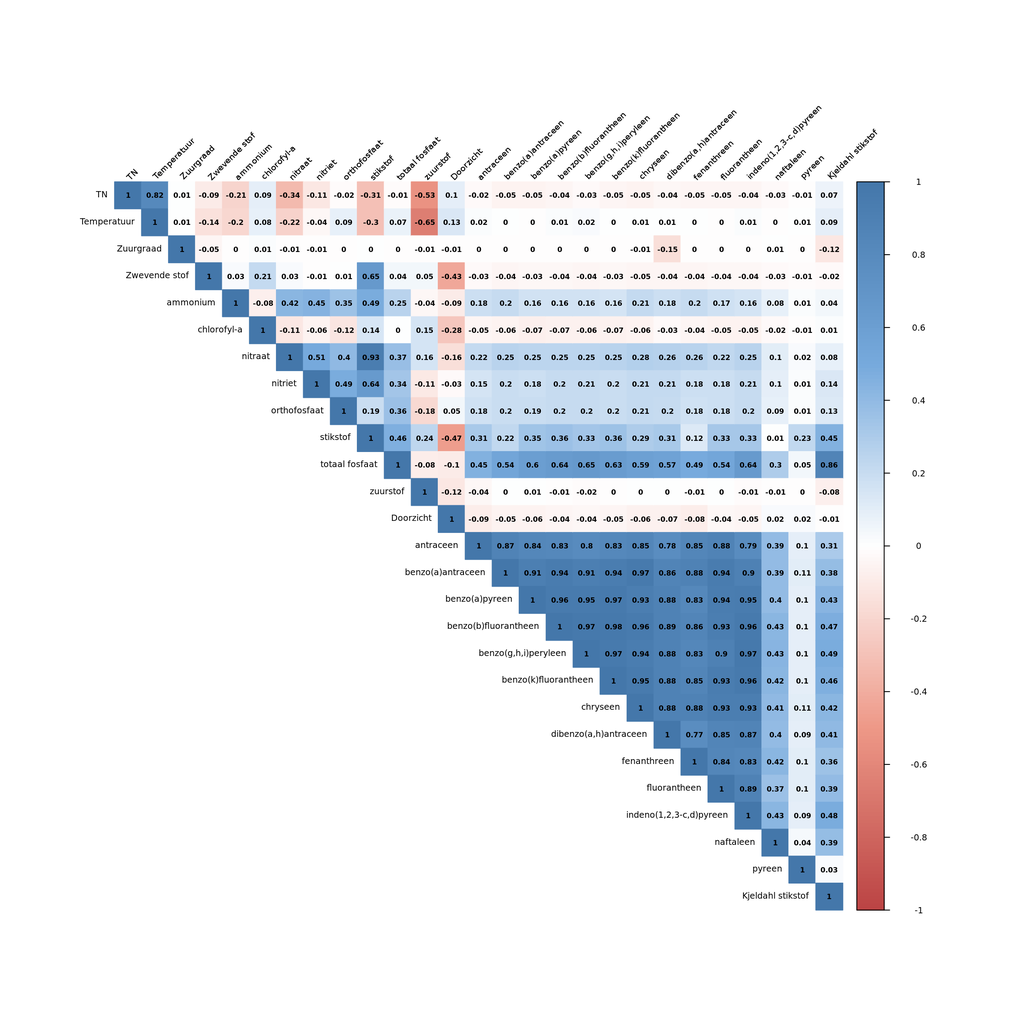

```r
library(corrplot)
na<- sapply(chloro_wide, function(y) sum(length(which(is.na(y)))))/nrow(chloro_wide) #beschikbaarheid per parameter

df_cors <- chloro_wide[,which(na <0.2)]
cors<- cor(chloro_wide[,4:(ncol(chloro_wide)-1)], use = "pairwise.complete.obs")


col <- colorRampPalette(c("#BB4444", "#EE9988", "#FFFFFF", "#77AADD", "#4477AA"))
corrplot(cors, method="color", col=col(200),
         type="upper", #order="hclust",
         tl.cex = 0.6,
         number.cex=0.5,
         cl.cex = 0.6,
         addCoef.col = "black", # Add coefficient of correlation
         tl.col="black", tl.srt=45, #Text label color and rotation
         # Combine with significance
         #p.mat = p.mat, sig.level = 0.01, insig = "blank",
         # hide correlation coefficient on the principal diagonal
         diag=TRUE
)
```

### Regressiemodellen

Met lineaire regressie en een aantal eenvoudige machine learning modellen kijken we vervolgens in hoeverre chrolofyl-a te modelleren is op basis van andere parameters.

Omdat niet alle meetlocaties een hoge beschikbaarheid hebben, selecteren we alleen de top 50 locaties met meeste chlorofyl-a metingen. Daarnaast heeft Marcel tijdens de intake een lijstje met locaties aangeleverd zie sowieso moeten worden meegenomen.

De plot laat de tijdlijn zien voor de geselecteerde locaties

```r
#We kijken alleen naar locaties met hoge beschikbaarheid of locaties uit de lijst in intakeformulier

lijst_marcel <- c("MAASSS","SASVGT","SCHAARVODLL","KEIZVR","NIEUWSS","BRAKL","ANDK","EIJSDPTN","LOBPTN","AMSDM","IJMDN1","KETMWT",
                  "BOCHTVWTM","HEEL","MARKMMDN","NIEUWGN","NOORDWK2","PUTTHK","SCHEELHK","VROUWZD","WIENE"
)

locs_top_n <- chl_agg %>% arrange(desc(n)) %>% head(50)

print(paste(sum(lijst_marcel %in% locs_top_n$LOC), "van de", length(lijst_marcel), "locaties uit de lijst van Marcel zijn geselecteerd. De andere",
            length(lijst_marcel)-sum(lijst_marcel %in% locs_top_n$LOC),"locaties hebben",
            paste(chl_agg$n[which(chl_agg$LOC %in% lijst_marcel[which(!(lijst_marcel %in% locs_top_n$LOC))])], collapse = ","),
            "observaties en voegen we ook nog toe."
))
```

[output not shown]

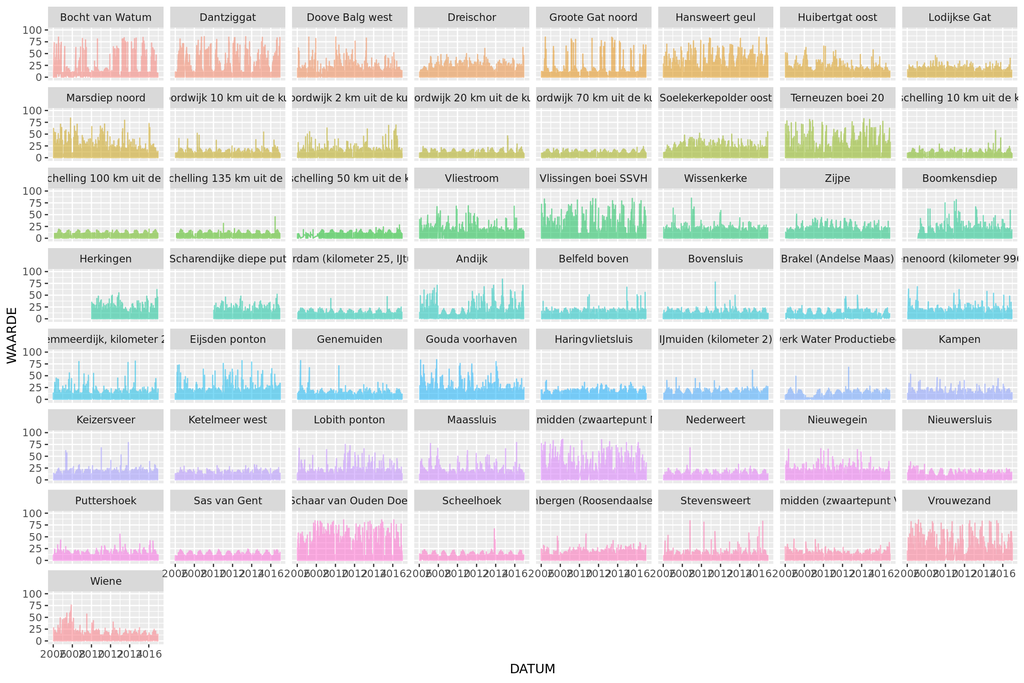

```r
locs <- unique(chl_agg$LOCOMS)[which( unique(chl_agg$LOC) %in% locs_top_n$LOC | unique(chl_agg$LOC) %in% lijst_marcel)]

df <- chloro_wide[which(chloro_wide$LOCOMS %in% locs),]

df <- droplevels(df)

chloro <- chloro[which(chloro$LOCOMS %in% locs),]



#ggplot(chloro, aes(x = factor(LOCOMS), y= WAARDE)) + geom_boxplot() #+ylim(-1,100)

#ggplot(chloro,aes(x = DATUM, y = WAARDE, color = LOCOMS)) + geom_line(alpha = 0.5) + facet_wrap(~SGB,nrow = 6) +guides(color=F) +ylim(-2,100)

ggplot(chloro,aes(x = DATUM, y = WAARDE, color = LOCOMS)) + geom_line(alpha = 0.5) + facet_wrap(~LOCOMS) +guides(color=F) +ylim(-2,100)
```

```r
###Machine learning pipeline -----

library(caret)


#remove na's
na<- sapply(chloro_wide, function(y) sum(length(which(is.na(y)))))/nrow(chloro_wide)

df_m <- df[,which(na <0.3)]

df_m <- df_m[complete.cases(df_m),]

colnames(df_m) <- gsub(" |-|\\(|\\)|,","", colnames(df_m))
cols <- colnames(df_m)
cols <- cols[which(!cols %in% c("chlorofyl-a", "DATUM", "YYYYMMDD", "HDH", "ANA", "na_count"))]
#cols[which(grepl(" ", cols))] <- paste0("`",cols[which(grepl(" ", cols))], "`" )

formula <- as.formula(paste("chlorofyla ~", paste(cols, collapse = "+")))

# define training control
train_control <- trainControl(method="repeatedcv", number=5, repeats = 3)

# lineair model
lm <- train(formula, data=df_m, trControl=train_control, method="lm",na.action = na.pass)
print(lm)
```

```
## Linear Regression
##
## 8268 samples
##   13 predictor
##
## No pre-processing
## Resampling: Cross-Validated (5 fold, repeated 3 times)
## Summary of sample sizes: 6614, 6614, 6616, 6613, 6615, 6614, ...
## Resampling results:
##
##   RMSE      Rsquared   MAE
##   6.974244  0.4539701  4.054304
##
## Tuning parameter 'intercept' was held constant at a value of TRUE
```

```r
summary(lm)
```

```
##
## Call:
## lm(formula = .outcome ~ ., data = dat)
##
## Residuals:
##     Min      1Q  Median      3Q     Max
## -39.852  -3.123  -0.938   1.561  73.985
##
## Coefficients: (3 not defined because of singularities)
##                                                      Estimate Std. Error
## (Intercept)                                        -48.728086   3.298223
## LOCOMSDantziggat                                    13.799980   0.814004
## `LOCOMSDoove Balg west`                              2.725041   0.894585
## LOCOMSDreischor                                     -1.479932   0.892461
## `LOCOMSGroote Gat noord`                             0.049129   0.799574
## `LOCOMSHansweert geul`                               2.955671   0.856580
## `LOCOMSHuibertgat oost`                              0.769068   0.834883
## `LOCOMSLodijkse Gat`                                -2.122663   0.836936
## `LOCOMSMarsdiep noord`                               2.773114   0.832856
## `LOCOMSNoordwijk 10 km uit de kust`                  0.362960   0.831661
## `LOCOMSNoordwijk 2 km uit de kust`                   2.186023   0.852346
## `LOCOMSNoordwijk 20 km uit de kust`                 -0.806364   0.867739
## `LOCOMSNoordwijk 70 km uit de kust`                 -2.775638   0.864784
## `LOCOMSSoelekerkepolder oost`                        0.380447   0.888519
## `LOCOMSTerneuzen boei 20`                            0.966438   0.845433
## `LOCOMSTerschelling 10 km uit de kust`              -1.261909   0.865932
## `LOCOMSTerschelling 100 km uit de kust`             -2.963497   0.932303
## `LOCOMSTerschelling 135 km uit de kust`             -2.823157   0.932222
## `LOCOMSTerschelling 50 km uit de kust`              -2.734520   0.912232
## LOCOMSVliestroom                                     1.275911   0.920681
## `LOCOMSVlissingen boei SSVH`                         1.748435   0.789863
## LOCOMSWissenkerke                                   -0.526768   0.883418
## LOCOMSZijpe                                         -0.641519   0.892426
## LOCOMSBoomkensdiep                                   1.560095   0.875251
## LOCOMSHerkingen                                     -1.941820   1.050100
## `LOCOMSScharendijke diepe put`                      -0.244119   1.053713
## `LOCOMSAmsterdam (kilometer 25, IJtunnel)`           4.886112   0.878556
## LOCOMSAndijk                                               NA         NA
## `LOCOMSBelfeld boven`                                2.983061   0.929357
## LOCOMSBovensluis                                     4.263483   0.898783
```

[output cut: 120 more lines]

```
## month4                                               9.722  < 2e-16 ***
## month5                                               4.981 6.45e-07 ***
## month6                                               0.710 0.477757
## month7                                              -0.720 0.471265
## month8                                              -2.318 0.020470 *
## month9                                              -2.750 0.005979 **
## month10                                             -3.356 0.000793 ***
## month11                                             -2.374 0.017614 *
## month12                                             -0.781 0.435036
## ---
## Signif. codes:  0 '***' 0.001 '**' 0.01 '*' 0.05 '.' 0.1 ' ' 1
##
## Residual standard error: 6.902 on 8192 degrees of freedom
## Multiple R-squared:  0.4687, Adjusted R-squared:  0.4639
## F-statistic: 96.38 on 75 and 8192 DF,  p-value: < 2.2e-16
```

```r
#rpart
rp <- train(formula, data=df_m, trControl=train_control, method="rpart",na.action = na.pass)
print(rp)
```

```
## CART
##
## 8268 samples
##   13 predictor
##
## No pre-processing
## Resampling: Cross-Validated (5 fold, repeated 3 times)
## Summary of sample sizes: 6615, 6615, 6614, 6614, 6614, 6616, ...
## Resampling results across tuning parameters:
##
##   cp         RMSE      Rsquared   MAE
##   0.0463300  7.983859  0.2807133  4.776127
##   0.0703851  8.278851  0.2282115  5.014610
##   0.1971353  9.143916  0.1465703  5.457054
##
## RMSE was used to select the optimal model using  the smallest value.
## The final value used for the model was cp = 0.04633.
```

```r
# #gbm
# gbm <- train(formula, data=df_m, trControl=train_control, method="gbm")
# print(gbm)
# varImp(gbm)
```